# Cort models eval

#### What happens to VIFs for linear model without interactions?

This should tell us whether max and min are worryingly collinear with each other.

| Term | VIF | VIF_CI_low | VIF_CI_high | SE_factor | Tolerance | Tolerance_CI_low | Tolerance_CI_high |
| --- | --- | --- | --- | --- | --- | --- | --- |
| meanmaxtempI_scaled | 2.413723 | 1.976059 | 3.047634 | 1.553616 | 0.4142978 | 0.32812341 | 0.5060577 |
| habitat | 1.455213 | 1.256340 | 1.808377 | 1.206322 | 0.6871845 | 0.55298212 | 0.7959630 |
| meanmintempI_scaled | 7.897479 | 6.143065 | 10.250362 | 2.810245 | 0.1266227 | 0.09755753 | 0.1627852 |
| age_scaled | 1.131274 | 1.035208 | 1.489464 | 1.063614 | 0.8839588 | 0.67138245 | 0.9659896 |
| juliandate_scaled | 2.589652 | 2.109343 | 3.277917 | 1.609239 | 0.3861523 | 0.30507180 | 0.4740812 |
| habitat:meanmintempI_scaled | 8.303099 | 6.451517 | 10.783562 | 2.881510 | 0.1204370 | 0.09273374 | 0.1550023 |

It looks like they aren’t, which is what I thought. So we should be good there.

### sqrt(abs_change_cort)

#### Plots

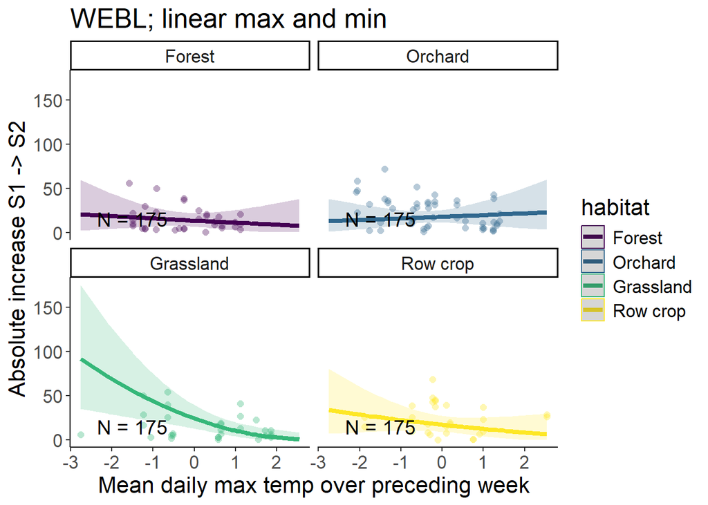

| Term | VIF | VIF_CI_low | VIF_CI_high | SE_factor | Tolerance | Tolerance_CI_low | Tolerance_CI_high |
| --- | --- | --- | --- | --- | --- | --- | --- |
| meanmaxtempI_scaled | 10.163529 | 7.757211 | 13.426764 | 3.188029 | 0.09839102 | 0.07447811 | 0.12891231 |
| habitat | 1.887496 | 1.564989 | 2.394098 | 1.373862 | 0.52980231 | 0.41769385 | 0.63898213 |
| meanmintempI_scaled | 9.768475 | 7.461307 | 12.899474 | 3.125456 | 0.10237012 | 0.07752254 | 0.13402477 |
| age_scaled | 1.244969 | 1.101767 | 1.589677 | 1.115782 | 0.80323285 | 0.62905841 | 0.90763278 |
| juliandate_scaled | 2.538997 | 2.049616 | 3.256551 | 1.593423 | 0.39385633 | 0.30707337 | 0.48789628 |
| year_fct | 1.237370 | 1.096766 | 1.582272 | 1.112371 | 0.80816594 | 0.63200248 | 0.91177124 |
| meanmaxtempI_scaled:habitat | 46.728386 | 35.147898 | 62.236134 | 6.835816 | 0.02140027 | 0.01606784 | 0.02845120 |
| habitat:meanmintempI_scaled | 53.402172 | 40.147325 | 71.144961 | 7.307679 | 0.01872583 | 0.01405581 | 0.02490826 |

| Term | VIF | VIF_CI_low | VIF_CI_high | SE_factor | Tolerance | Tolerance_CI_low | Tolerance_CI_high |
| --- | --- | --- | --- | --- | --- | --- | --- |
| poly(meanmaxtempI_scaled, 2) | 204.149509 | 153.074645 | 272.378066 | 14.288090 | 0.004898371 | 0.003671368 | 0.006532761 |
| habitat | 1.281245 | 1.126069 | 1.627424 | 1.131921 | 0.780491091 | 0.614467944 | 0.888045317 |
| age_scaled | 1.173041 | 1.056262 | 1.532214 | 1.083070 | 0.852485066 | 0.652650406 | 0.946735147 |
| juliandate_scaled | 1.896114 | 1.571369 | 2.405434 | 1.376995 | 0.527394352 | 0.415725429 | 0.636387869 |
| year_fct | 1.175005 | 1.057436 | 1.533236 | 1.083977 | 0.851060116 | 0.652215230 | 0.945683978 |
| poly(meanmaxtempI_scaled, 2):habitat | 248.594956 | 186.369489 | 331.708482 | 15.766894 | 0.004022608 | 0.003014695 | 0.005365685 |

This response seems a little bit rough in the model dept. Tough to tell what exactly is going on - got several errors when graphing and checking performance.

#### Plots

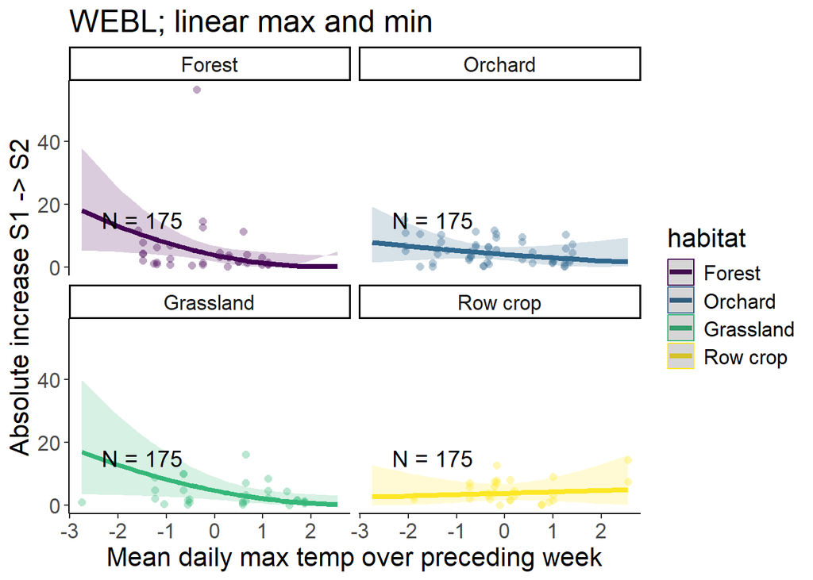

| Term | VIF | VIF_CI_low | VIF_CI_high | SE_factor | Tolerance | Tolerance_CI_low | Tolerance_CI_high |
| --- | --- | --- | --- | --- | --- | --- | --- |
| meanmaxtempI_scaled | 10.163529 | 7.757211 | 13.426764 | 3.188029 | 0.09839102 | 0.07447811 | 0.12891231 |
| habitat | 1.887496 | 1.564989 | 2.394098 | 1.373862 | 0.52980231 | 0.41769385 | 0.63898213 |
| meanmintempI_scaled | 9.768475 | 7.461307 | 12.899474 | 3.125456 | 0.10237012 | 0.07752254 | 0.13402477 |
| age_scaled | 1.244969 | 1.101767 | 1.589677 | 1.115782 | 0.80323285 | 0.62905841 | 0.90763278 |
| juliandate_scaled | 2.538997 | 2.049616 | 3.256551 | 1.593423 | 0.39385633 | 0.30707337 | 0.48789628 |
| year_fct | 1.237370 | 1.096766 | 1.582272 | 1.112371 | 0.80816594 | 0.63200248 | 0.91177124 |
| meanmaxtempI_scaled:habitat | 46.728386 | 35.147898 | 62.236134 | 6.835816 | 0.02140027 | 0.01606784 | 0.02845120 |
| habitat:meanmintempI_scaled | 53.402172 | 40.147325 | 71.144961 | 7.307679 | 0.01872583 | 0.01405581 | 0.02490826 |

| Term | VIF | VIF_CI_low | VIF_CI_high | SE_factor | Tolerance | Tolerance_CI_low | Tolerance_CI_high |
| --- | --- | --- | --- | --- | --- | --- | --- |
| poly(meanmaxtempI_scaled, 2) | 204.149509 | 153.074645 | 272.378066 | 14.288090 | 0.004898371 | 0.003671368 | 0.006532761 |
| habitat | 1.281245 | 1.126069 | 1.627424 | 1.131921 | 0.780491091 | 0.614467944 | 0.888045317 |
| age_scaled | 1.173041 | 1.056262 | 1.532214 | 1.083070 | 0.852485066 | 0.652650406 | 0.946735147 |
| juliandate_scaled | 1.896114 | 1.571369 | 2.405434 | 1.376995 | 0.527394352 | 0.415725429 | 0.636387869 |
| year_fct | 1.175005 | 1.057436 | 1.533236 | 1.083977 | 0.851060116 | 0.652215230 | 0.945683978 |
| poly(meanmaxtempI_scaled, 2):habitat | 248.594956 | 186.369489 | 331.708482 | 15.766894 | 0.004022608 | 0.003014695 | 0.005365685 |

This response seems a little bit rough in the model dept. Tough to tell what exactly is going on because I got so many errors.

### Conclusions:

I like sqrt(cort_s1) as a response better than the others. There seems to be more signal there, and it’s the most normal response.

Revisiting those two models, I think an argument could be made for either. The VIFs are inflated by the interaction terms for both models, and when I run the linear model without the max * habitat interaction, its VIF is under the threshold.

I like the idea of parsing out the effect of max temp from min temp, could be a useful comparison to make with previous work looking at the cort effects of cold. This is something I’d like to bring up in lab meeting - maybe crowdsource some thoughts about what those two models tell us.

Looks like row crop is significantly different from forest with linear temp, but not with squared temp. Another less rigorous argument for linear temp. It is also so much easier to interpret the coefficients with linear temp!!!

## TRES

### sqrt(cort_s1)

#### Plots

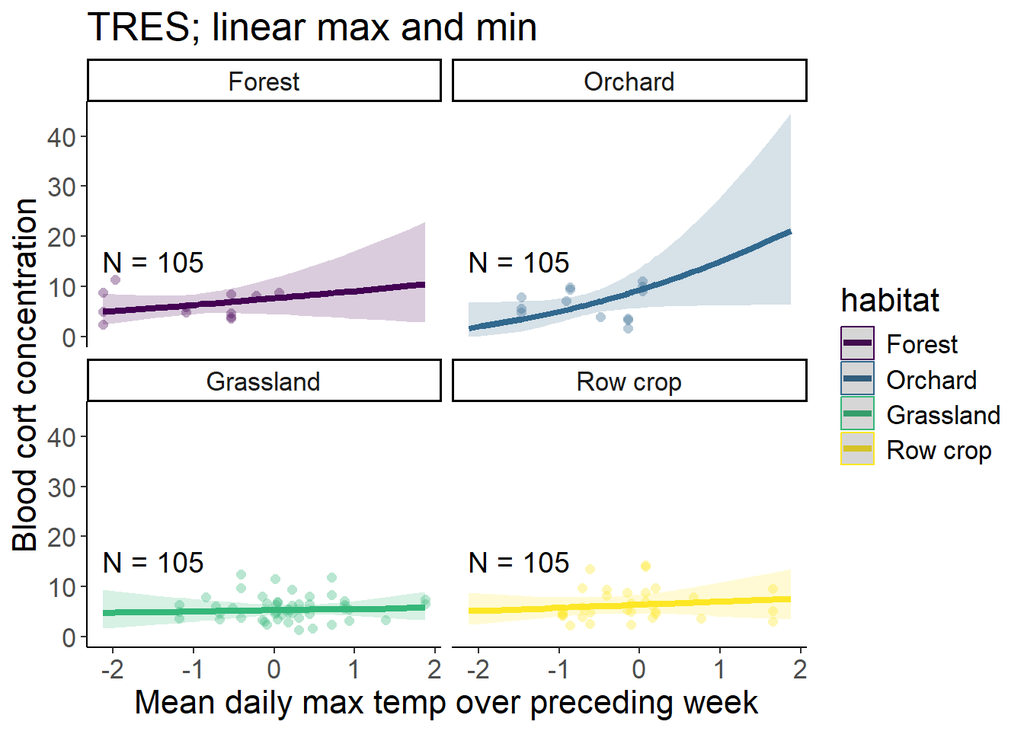

```
## Linear mixed model fit by REML. t-tests use Satterthwaite's method [
## lmerModLmerTest]
## Formula: sqrt(cort_s1) ~ meanmaxtempI_scaled * habitat + meanmintempI_scaled *
##     habitat + age_scaled + juliandate_scaled + year_fct + (1 |      attempt_id)
##    Data:
## dplyr::filter(g, Species == "TRES", !is.na(meanmaxtempI), !is.na(meanmintempI)) %>%
##     mutate(across(c(gweight, meanmaxtempI, meanmintempI, juliandate,
##         brood_size, age), ~scale(.x)[, 1], .names = "{.col}_scaled"),
##         meanmaxtempI_scaled_sq = meanmaxtempI_scaled * meanmaxtempI_scaled)
##
## REML criterion at convergence: 190.3
##
## Scaled residuals:
##      Min       1Q   Median       3Q      Max
## -1.97197 -0.59931 -0.04445  0.56632  2.10587
##
## Random effects:
##  Groups     Name        Variance Std.Dev.
##  attempt_id (Intercept) 0.02699  0.1643
##  Residual               0.28859  0.5372
## Number of obs: 105, groups:  attempt_id, 41
##
## Fixed effects:
##                                      Estimate Std. Error       df t value
## (Intercept)                           2.86437    0.36738 53.79672   7.797
## meanmaxtempI_scaled                   0.25180    0.26057 36.00984   0.966
## habitatOrchard                       -0.01401    0.45870 41.90127  -0.031
## habitatGrassland                     -0.57198    0.37114 50.96682  -1.541
## habitatRow crop                      -0.32213    0.41124 43.73650  -0.783
## meanmintempI_scaled                  -0.53737    0.30022 37.67660  -1.790
## age_scaled                            0.02233    0.07387 52.96052   0.302
## juliandate_scaled                     0.02554    0.07850 28.14129   0.325
## year_fct2023                          0.02879    0.16662 24.18324   0.173
## meanmaxtempI_scaled:habitatOrchard    0.57573    0.48455 27.87866   1.188
## meanmaxtempI_scaled:habitatGrassland -0.19520    0.30774 37.32213  -0.634
## meanmaxtempI_scaled:habitatRow crop  -0.12454    0.31613 28.86919  -0.394
## habitatOrchard:meanmintempI_scaled    1.40521    0.41651 32.71950   3.374
## habitatGrassland:meanmintempI_scaled  0.49012    0.31540 36.12902   1.554
## habitatRow crop:meanmintempI_scaled   0.39738    0.37747 30.38761   1.053
##                                      Pr(>|t|)
## (Intercept)                          2.15e-10 ***
## meanmaxtempI_scaled                   0.34032
## habitatOrchard                        0.97578
## habitatGrassland                      0.12947
## habitatRow crop                       0.43766
## meanmintempI_scaled                   0.08150 .
## age_scaled                            0.76363
## juliandate_scaled                     0.74728
## year_fct2023                          0.86427
## meanmaxtempI_scaled:habitatOrchard    0.24479
## meanmaxtempI_scaled:habitatGrassland  0.52975
## meanmaxtempI_scaled:habitatRow crop   0.69652
## habitatOrchard:meanmintempI_scaled    0.00192 **
## habitatGrassland:meanmintempI_scaled  0.12891
## habitatRow crop:meanmintempI_scaled   0.30076
## ---
## Signif. codes:  0 '***' 0.001 '**' 0.01 '*' 0.05 '.' 0.1 ' ' 1
```

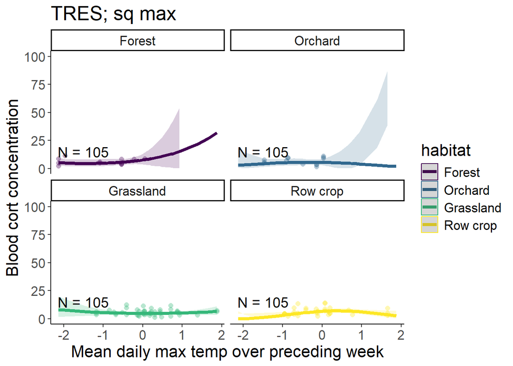

```
## Linear mixed model fit by REML. t-tests use Satterthwaite's method [
## lmerModLmerTest]
## Formula: sqrt(cort_s1) ~ poly(meanmaxtempI_scaled, 2) * habitat + age_scaled +
##     juliandate_scaled + year_fct + (1 | attempt_id)
##    Data:
## dplyr::filter(g, Species == "TRES", !is.na(meanmaxtempI), !is.na(meanmintempI)) %>%
##     mutate(across(c(gweight, meanmaxtempI, meanmintempI, juliandate,
##         brood_size, age), ~scale(.x)[, 1], .names = "{.col}_scaled"),
##         meanmaxtempI_scaled_sq = meanmaxtempI_scaled * meanmaxtempI_scaled)
##
## REML criterion at convergence: 138.8
##
## Scaled residuals:
##      Min       1Q   Median       3Q      Max
## -2.09350 -0.60830 -0.03807  0.54821  2.20998
##
## Random effects:
##  Groups     Name        Variance Std.Dev.
##  attempt_id (Intercept) 0.0594   0.2437
##  Residual               0.2865   0.5353
## Number of obs: 105, groups:  attempt_id, 41
##
## Fixed effects:
##                                                  Estimate Std. Error         df
## (Intercept)                                     3.089e+00  8.140e-01  5.903e+01
## poly(meanmaxtempI_scaled, 2)1                   2.480e+01  3.031e+01  4.649e+01
## poly(meanmaxtempI_scaled, 2)2                   1.498e+01  2.067e+01  4.093e+01
## habitatOrchard                                 -9.613e-01  1.215e+00  5.929e+01
## habitatGrassland                               -7.682e-01  8.300e-01  5.801e+01
## habitatRow crop                                -9.642e-01  8.349e-01  5.662e+01
## age_scaled                                     -4.663e-02  8.400e-02  5.789e+01
## juliandate_scaled                              -7.108e-04  8.647e-02  3.039e+01
## year_fct2023                                    3.395e-01  1.790e-01  2.621e+01
## poly(meanmaxtempI_scaled, 2)1:habitatOrchard   -3.172e+01  4.713e+01  6.145e+01
## poly(meanmaxtempI_scaled, 2)2:habitatOrchard   -2.394e+01  3.807e+01  7.310e+01
## poly(meanmaxtempI_scaled, 2)1:habitatGrassland -2.263e+01  3.035e+01  4.677e+01
## poly(meanmaxtempI_scaled, 2)2:habitatGrassland -9.012e+00  2.129e+01  4.239e+01
## poly(meanmaxtempI_scaled, 2)1:habitatRow crop  -2.863e+01  3.035e+01  4.573e+01
## poly(meanmaxtempI_scaled, 2)2:habitatRow crop  -3.574e+01  2.193e+01  3.759e+01
##                                                t value Pr(>|t|)
## (Intercept)                                      3.795  0.00035 ***
## poly(meanmaxtempI_scaled, 2)1                    0.818  0.41747
## poly(meanmaxtempI_scaled, 2)2                    0.725  0.47266
## habitatOrchard                                  -0.791  0.43193
## habitatGrassland                                -0.926  0.35851
## habitatRow crop                                 -1.155  0.25296
## age_scaled                                      -0.555  0.58093
## juliandate_scaled                               -0.008  0.99350
## year_fct2023                                     1.896  0.06900 .
## poly(meanmaxtempI_scaled, 2)1:habitatOrchard    -0.673  0.50354
## poly(meanmaxtempI_scaled, 2)2:habitatOrchard    -0.629  0.53138
## poly(meanmaxtempI_scaled, 2)1:habitatGrassland  -0.746  0.45954
## poly(meanmaxtempI_scaled, 2)2:habitatGrassland  -0.423  0.67429
## poly(meanmaxtempI_scaled, 2)1:habitatRow crop   -0.944  0.35038
## poly(meanmaxtempI_scaled, 2)2:habitatRow crop   -1.630  0.11145
## ---
## Signif. codes:  0 '***' 0.001 '**' 0.01 '*' 0.05 '.' 0.1 ' ' 1
```

[output not shown]

[output cut: 95 more lines]

[output not shown]

[output cut: 95 more lines]

| Term | VIF | VIF_CI_low | VIF_CI_high | SE_factor | Tolerance | Tolerance_CI_low | Tolerance_CI_high |
| --- | --- | --- | --- | --- | --- | --- | --- |
| meanmaxtempI_scaled | 12.860988 | 9.499811 | 17.551312 | 3.586222 | 0.077754525 | 0.056975798 | 0.105265247 |
| habitat | 25.349279 | 18.570201 | 34.743917 | 5.034807 | 0.039448854 | 0.028782017 | 0.053849714 |
| meanmintempI_scaled | 26.582721 | 19.466085 | 36.442034 | 5.155843 | 0.037618422 | 0.027440839 | 0.051371399 |
| age_scaled | 1.228567 | 1.082489 | 1.633329 | 1.108407 | 0.813956574 | 0.612246631 | 0.923796759 |
| juliandate_scaled | 1.919573 | 1.561341 | 2.506418 | 1.385486 | 0.520949235 | 0.398975746 | 0.640475079 |
| year_fct | 1.911743 | 1.555731 | 2.495823 | 1.382658 | 0.523082897 | 0.400669472 | 0.642784654 |
| meanmaxtempI_scaled:habitat | 59.074764 | 43.066263 | 81.175370 | 7.686011 | 0.016927702 | 0.012319008 | 0.023220032 |
| habitat:meanmintempI_scaled | 172.540499 | 125.481245 | 237.390170 | 13.135467 | 0.005795741 | 0.004212474 | 0.007969318 |

| Term | VIF | VIF_CI_low | VIF_CI_high | SE_factor | Tolerance | Tolerance_CI_low | Tolerance_CI_high |
| --- | --- | --- | --- | --- | --- | --- | --- |
| poly(meanmaxtempI_scaled, 2) | 566.947365 | 411.956032 | 780.393404 | 23.810657 | 1.763832e-03 | 1.281405e-03 | 0.002427444 |
| habitat | 578.915755 | 420.649192 | 796.870994 | 24.060668 | 1.727367e-03 | 1.254908e-03 | 0.002377278 |
| age_scaled | 1.360087 | 1.167779 | 1.772818 | 1.166228 | 7.352470e-01 | 5.640736e-01 | 0.856326279 |
| juliandate_scaled | 1.869406 | 1.525420 | 2.438595 | 1.367262 | 5.349293e-01 | 4.100721e-01 | 0.655557115 |
| year_fct | 1.757765 | 1.445711 | 2.288297 | 1.325807 | 5.689042e-01 | 4.370062e-01 | 0.691701201 |
| poly(meanmaxtempI_scaled, 2):habitat | 13666.375204 | 9926.638956 | 18815.151945 | 116.903273 | 7.317229e-05 | 5.314865e-05 | 0.000100739 |

#### What happens to VIFs for without interactions?

This should tell us whether max and min are worryingly collinear with each other.

| Term | VIF | VIF_CI_low | VIF_CI_high | SE_factor | Tolerance | Tolerance_CI_low | Tolerance_CI_high |
| --- | --- | --- | --- | --- | --- | --- | --- |
| meanmaxtempI_scaled | 2.496123 | 1.958025 | 3.336456 | 1.579912 | 0.40062130 | 0.29971918 | 0.51071871 |
| habitat | 3.771903 | 2.868556 | 5.111970 | 1.942139 | 0.26511817 | 0.19561929 | 0.34860748 |
| meanmintempI_scaled | 21.028270 | 15.220743 | 29.207501 | 4.585659 | 0.04755503 | 0.03423778 | 0.06569982 |
| age_scaled | 1.157486 | 1.039037 | 1.635350 | 1.075865 | 0.86394098 | 0.61149002 | 0.96242986 |
| juliandate_scaled | 1.631796 | 1.347254 | 2.149493 | 1.277418 | 0.61282166 | 0.46522607 | 0.74225033 |
| habitat:meanmintempI_scaled | 46.745406 | 33.633431 | 65.125719 | 6.837061 | 0.02139248 | 0.01535492 | 0.02973232 |

| Term | VIF | VIF_CI_low | VIF_CI_high | SE_factor | Tolerance | Tolerance_CI_low | Tolerance_CI_high |
| --- | --- | --- | --- | --- | --- | --- | --- |
| poly(meanmaxtempI_scaled, 2) | 2.502574 | 1.953443 | 3.367974 | 1.581953 | 0.3995886 | 0.2969144 | 0.5119166 |
| habitat | 1.719433 | 1.403422 | 2.282982 | 1.311271 | 0.5815872 | 0.4380236 | 0.7125440 |
| age_scaled | 1.201658 | 1.061503 | 1.661205 | 1.096202 | 0.8321837 | 0.6019727 | 0.9420608 |
| juliandate_scaled | 1.762190 | 1.433124 | 2.341267 | 1.327475 | 0.5674755 | 0.4271192 | 0.6977765 |
| year_fct | 1.520663 | 1.266686 | 2.016512 | 1.233151 | 0.6576081 | 0.4959057 | 0.7894617 |

### sqrt(abs_change_cort)

#### Plots

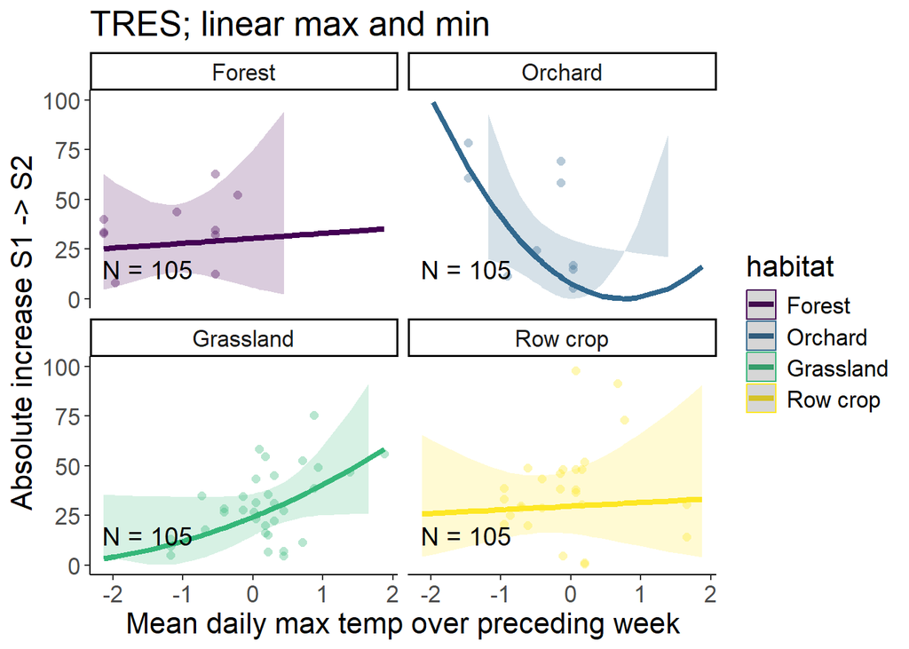

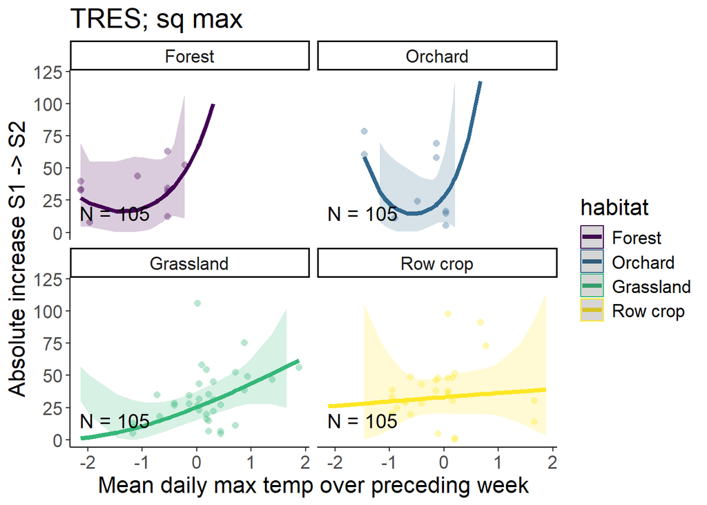

I feel like there’s just not enough data in forest and orchard to model those. I wonder if filtering to just grassland and row crop would help here.

[output not shown]

[output cut: 70 more lines]

[output not shown]

[output cut: 70 more lines]

| Term | VIF | VIF_CI_low | VIF_CI_high | SE_factor | Tolerance | Tolerance_CI_low | Tolerance_CI_high |
| --- | --- | --- | --- | --- | --- | --- | --- |
| meanmaxtempI_scaled | 16.482587 | 11.852089 | 23.088879 | 4.059875 | 0.060670089 | 0.043310894 | 0.08437331 |
| habitat | 29.897727 | 21.359863 | 42.015927 | 5.467881 | 0.033447358 | 0.023800499 | 0.04681678 |
| meanmintempI_scaled | 21.491829 | 15.402264 | 30.156182 | 4.635928 | 0.046529312 | 0.033160696 | 0.06492552 |
| age_scaled | 1.539005 | 1.277592 | 2.046594 | 1.240566 | 0.649770453 | 0.488616659 | 0.78272234 |
| juliandate_scaled | 2.172577 | 1.717613 | 2.915989 | 1.473966 | 0.460282830 | 0.342936874 | 0.58220349 |
| year_fct | 1.870706 | 1.506429 | 2.497010 | 1.367737 | 0.534557640 | 0.400479047 | 0.66382173 |
| meanmaxtempI_scaled:habitat | 64.236430 | 45.697493 | 90.464661 | 8.014763 | 0.015567490 | 0.011054040 | 0.02188304 |
| habitat:meanmintempI_scaled | 138.665598 | 98.449663 | 195.478012 | 11.775636 | 0.007211594 | 0.005115665 | 0.01015748 |

| Term | VIF | VIF_CI_low | VIF_CI_high | SE_factor | Tolerance | Tolerance_CI_low | Tolerance_CI_high |
| --- | --- | --- | --- | --- | --- | --- | --- |
| meanmaxtempI_scaled | 2.654210 | 2.013090 | 3.701054 | 1.629175 | 0.3767600 | 0.2701933 | 0.4967489 |
| habitat | 1.887022 | 1.492316 | 2.598176 | 1.373689 | 0.5299355 | 0.3848853 | 0.6700993 |
| meanmintempI_scaled | 1.621193 | 1.314842 | 2.225633 | 1.273261 | 0.6168298 | 0.4493104 | 0.7605478 |
| age_scaled | 1.266883 | 1.090460 | 1.787383 | 1.125559 | 0.7893390 | 0.5594771 | 0.9170445 |
| juliandate_scaled | 2.012625 | 1.577020 | 2.777077 | 1.418670 | 0.4968635 | 0.3600909 | 0.6341072 |
| year_fct | 1.483737 | 1.224945 | 2.040261 | 1.218087 | 0.6739740 | 0.4901333 | 0.8163634 |

| Term | VIF | VIF_CI_low | VIF_CI_high | SE_factor | Tolerance | Tolerance_CI_low | Tolerance_CI_high |
| --- | --- | --- | --- | --- | --- | --- | --- |
| poly(meanmaxtempI_scaled, 2) | 1653.506228 | 1172.104845 | 2332.795352 | 40.663328 | 6.047755e-04 | 4.286703e-04 | 8.531660e-04 |
| habitat | 2590.572049 | 1836.257638 | 3654.919349 | 50.897663 | 3.860151e-04 | 2.736038e-04 | 5.445859e-04 |
| age_scaled | 2.201788 | 1.738118 | 2.956725 | 1.483842 | 4.541764e-01 | 3.382121e-01 | 5.753349e-01 |
| juliandate_scaled | 2.320421 | 1.821484 | 3.122395 | 1.523293 | 4.309562e-01 | 3.202670e-01 | 5.490030e-01 |
| year_fct | 1.755339 | 1.426262 | 2.338467 | 1.324892 | 5.696904e-01 | 4.276305e-01 | 7.011335e-01 |
| poly(meanmaxtempI_scaled, 2):habitat | 51549.191221 | 36536.065348 | 72731.567001 | 227.044470 | 1.939895e-05 | 1.374919e-05 | 2.737022e-05 |

| Term | VIF | VIF_CI_low | VIF_CI_high | SE_factor | Tolerance | Tolerance_CI_low | Tolerance_CI_high |
| --- | --- | --- | --- | --- | --- | --- | --- |
| poly(meanmaxtempI_scaled, 2) | 3.476515 | 2.575104 | 4.893790 | 1.864541 | 0.2876444 | 0.2043406 | 0.3883338 |
| habitat | 1.975955 | 1.552254 | 2.724730 | 1.405687 | 0.5060843 | 0.3670089 | 0.6442245 |
| age_scaled | 1.640217 | 1.327419 | 2.251844 | 1.280709 | 0.6096755 | 0.4440806 | 0.7533416 |
| juliandate_scaled | 2.158883 | 1.676039 | 2.986585 | 1.469314 | 0.4632026 | 0.3348306 | 0.5966449 |
| year_fct | 1.490654 | 1.229416 | 2.049363 | 1.220923 | 0.6708466 | 0.4879565 | 0.8133940 |

#### Plots

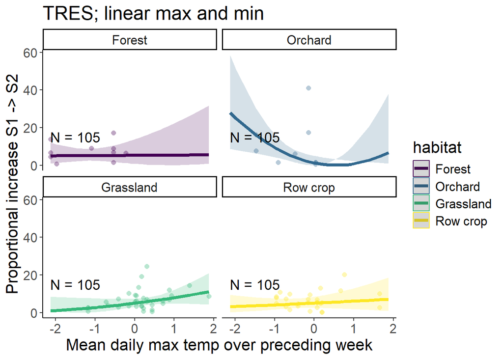

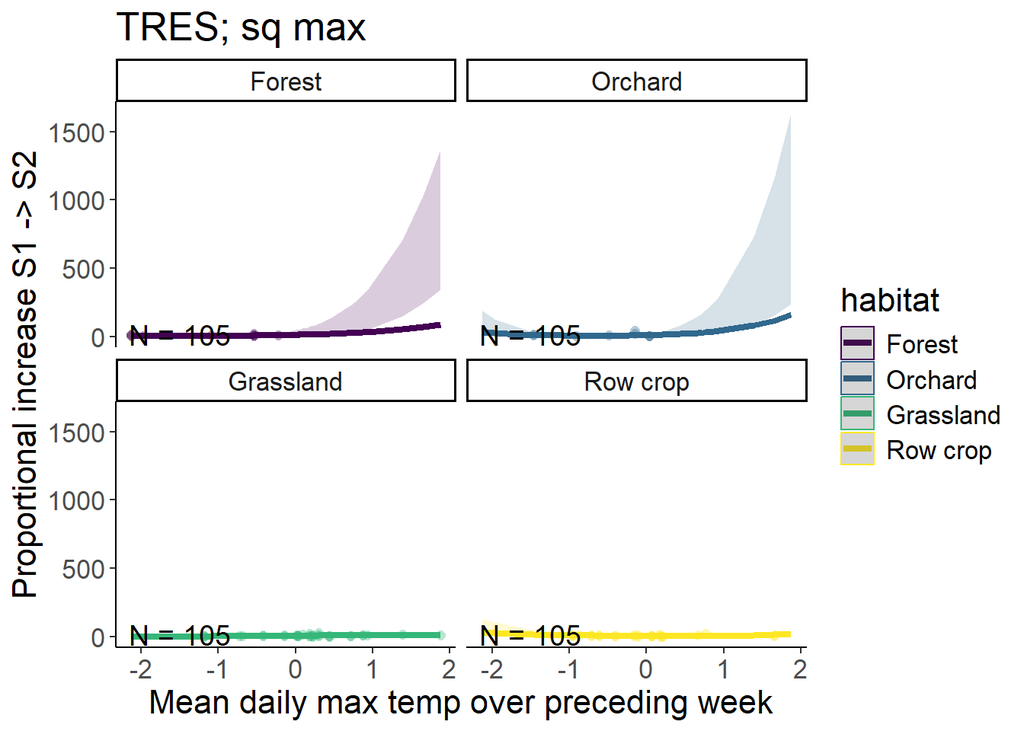

[output not shown]

[output cut: 70 more lines]

[output not shown]

[output cut: 70 more lines]

| Term | VIF | VIF_CI_low | VIF_CI_high | SE_factor | Tolerance | Tolerance_CI_low | Tolerance_CI_high |
| --- | --- | --- | --- | --- | --- | --- | --- |
| meanmaxtempI_scaled | 2.654210 | 2.013090 | 3.701054 | 1.629175 | 0.3767600 | 0.2701933 | 0.4967489 |
| habitat | 1.887022 | 1.492316 | 2.598176 | 1.373689 | 0.5299355 | 0.3848853 | 0.6700993 |
| meanmintempI_scaled | 1.621193 | 1.314842 | 2.225633 | 1.273261 | 0.6168298 | 0.4493104 | 0.7605478 |
| age_scaled | 1.266883 | 1.090460 | 1.787383 | 1.125559 | 0.7893390 | 0.5594771 | 0.9170445 |
| juliandate_scaled | 2.012625 | 1.577020 | 2.777077 | 1.418670 | 0.4968635 | 0.3600909 | 0.6341072 |
| year_fct | 1.483737 | 1.224945 | 2.040261 | 1.218087 | 0.6739740 | 0.4901333 | 0.8163634 |

| Term | VIF | VIF_CI_low | VIF_CI_high | SE_factor | Tolerance | Tolerance_CI_low | Tolerance_CI_high |
| --- | --- | --- | --- | --- | --- | --- | --- |
| poly(meanmaxtempI_scaled, 2) | 3.476515 | 2.575104 | 4.893790 | 1.864541 | 0.2876444 | 0.2043406 | 0.3883338 |
| habitat | 1.975955 | 1.552254 | 2.724730 | 1.405687 | 0.5060843 | 0.3670089 | 0.6442245 |
| age_scaled | 1.640217 | 1.327419 | 2.251844 | 1.280709 | 0.6096755 | 0.4440806 | 0.7533416 |
| juliandate_scaled | 2.158883 | 1.676039 | 2.986585 | 1.469314 | 0.4632026 | 0.3348306 | 0.5966449 |
| year_fct | 1.490654 | 1.229416 | 2.049363 | 1.220923 | 0.6708466 | 0.4879565 | 0.8133940 |

This response seems a little bit rough in the model dept. Tough to tell what exactly is going on, but again I do like the simplicity of the linear model.

### Conclusions:

For TRES, I like both cort_s1 and absolute increase. prop increase has a singular fit and looks sketchier when graphed. Could consider comparing just grassland and row crop for TRES cort as forest and orchard have very few data points.

With how little data TRES cort has, I think I’d argue for the simplicity of max and min temp. The VIFs indicate including both is not a problem.

I like the idea of parsing out the effect of max temp from min temp, could be a useful comparison to make with previous work looking at the cort effects of cold, and matches our pre-existing expectation that cold and hot operate differently. This is something I’d like to bring up in lab meeting - maybe crowdsource some thoughts about what those two models tell us.

There might not be much going on (or enough data to identify trends) for TRES cort and temp.

## Now that we have determined the temp structure for cort, does the interaction with habitat help the model?

Will check interaction with max and min.

### WEBL

| model | npar | AIC | BIC | logLik | deviance | Chisq | Df | Pr(>Chisq) |
| --- | --- | --- | --- | --- | --- | --- | --- | --- |
| no int | 11 | 278.4876 | 313.3002 | -128.2438 | 256.4876 | NA | NA | NA |
| int max | 14 | 280.5019 | 324.8089 | -126.2509 | 252.5019 | 3.985709 | 3 | 0.2630115 |
| int max and min | 17 | 284.6329 | 338.4343 | -125.3165 | 250.6329 | 1.868949 | 3 | 0.6000469 |

| model | npar | AIC | BIC | logLik | deviance | Chisq | Df | Pr(>Chisq) |
| --- | --- | --- | --- | --- | --- | --- | --- | --- |
| no int | 11 | 278.4876 | 313.3002 | -128.2438 | 256.4876 | NA | NA | NA |
| int min | 14 | 283.9373 | 328.2443 | -127.9687 | 255.9373 | 0.5502621 | 3 | 0.9077181 |
| int max and min | 17 | 284.6329 | 338.4343 | -125.3165 | 250.6329 | 5.3043959 | 3 | 0.1508174 |

Looks like there is not an interactive effect of temp and habitat for cort in nestling WEBL.

```
## Linear mixed model fit by REML. t-tests use Satterthwaite's method [
## lmerModLmerTest]
## Formula: sqrt(cort_s1) ~ meanmaxtempI_scaled + meanmintempI_scaled + habitat +
##     age_scaled + juliandate_scaled + year_fct + (1 | attempt_id)
##    Data:
## dplyr::filter(g, Species == "WEBL", !is.na(meanmaxtempI), !is.na(meanmintempI)) %>%
##     mutate(across(c(gweight, meanmaxtempI, meanmintempI, juliandate,
##         brood_size, age), ~scale(.x)[, 1], .names = "{.col}_scaled"),
##         meanmaxtempI_scaled_sq = meanmaxtempI_scaled * meanmaxtempI_scaled)
##
## REML criterion at convergence: 285.1
##
## Scaled residuals:
##     Min      1Q  Median      3Q     Max
## -3.2761 -0.5391 -0.0213  0.5440  3.9355
##
## Random effects:
##  Groups     Name        Variance Std.Dev.
##  attempt_id (Intercept) 0.08053  0.2838
##  Residual               0.21251  0.4610
## Number of obs: 175, groups:  attempt_id, 52
##
## Fixed effects:
##                      Estimate Std. Error        df t value Pr(>|t|)
## (Intercept)           2.22300    0.11801  35.25582  18.837   <2e-16 ***
## meanmaxtempI_scaled   0.03773    0.07544  90.49454   0.500   0.6182
## meanmintempI_scaled   0.07665    0.08328  48.24239   0.920   0.3620
## habitatOrchard       -0.03395    0.14452  34.67391  -0.235   0.8156
## habitatGrassland      0.05303    0.17247  32.84167   0.307   0.7604
## habitatRow crop       0.12072    0.16803  36.61915   0.718   0.4770
## age_scaled            0.09576    0.04425 165.76178   2.164   0.0319 *
## juliandate_scaled    -0.22199    0.08627  51.20781  -2.573   0.0130 *
## year_fct2023          0.08177    0.12664  38.16479   0.646   0.5223
## ---
## Signif. codes:  0 '***' 0.001 '**' 0.01 '*' 0.05 '.' 0.1 ' ' 1
##
## Correlation of Fixed Effects:
##             (Intr) mnmxI_ mnmnI_ hbttOr hbttGr hbttRc ag_scl jlndt_
## mnmxtmpI_sc  0.055
## mnmntmpI_sc  0.111 -0.458
## habttOrchrd -0.740  0.039 -0.128
## hbttGrsslnd -0.560 -0.248  0.260  0.444
## habittRwcrp -0.622 -0.168  0.010  0.498  0.430
## age_scaled   0.052  0.031  0.003 -0.143 -0.055 -0.132
## julndt_scld -0.063 -0.302 -0.482  0.050 -0.115  0.128 -0.128
## yer_fct2023 -0.347  0.319 -0.233  0.108 -0.106 -0.018  0.095 -0.136
```

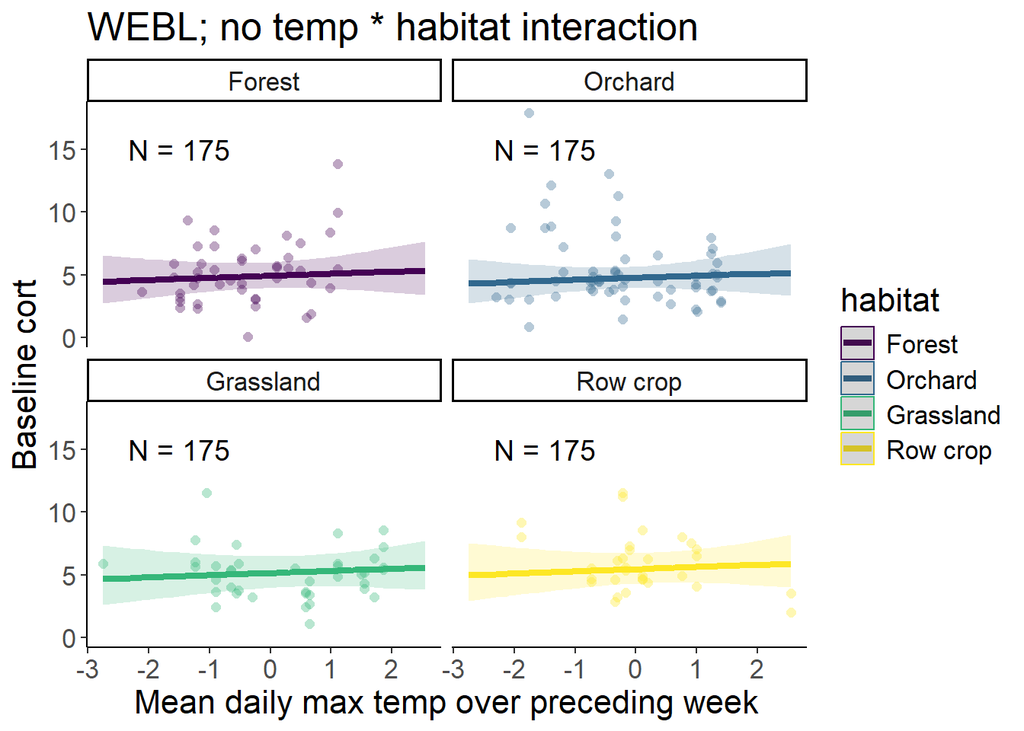

#### abs_change_cort

| model | npar | AIC | BIC | logLik | deviance | Chisq | Df | Pr(>Chisq) |
| --- | --- | --- | --- | --- | --- | --- | --- | --- |
| no int | 11 | 556.9294 | 589.4435 | -267.4647 | 534.9294 | NA | NA | NA |
| int max | 14 | 562.7790 | 604.1606 | -267.3895 | 534.7790 | 0.1503821 | 3 | 0.985171257 |
| int max and min | 17 | 555.2606 | 605.5097 | -260.6303 | 521.2606 | 13.5183660 | 3 | 0.003639744 |

| model | npar | AIC | BIC | logLik | deviance | Chisq | Df | Pr(>Chisq) |
| --- | --- | --- | --- | --- | --- | --- | --- | --- |
| no int | 11 | 556.9294 | 589.4435 | -267.4647 | 534.9294 | NA | NA | NA |
| int min | 14 | 557.5764 | 598.9580 | -264.7882 | 529.5764 | 5.352956 | 3 | 0.14770281 |
| int max and min | 17 | 555.2606 | 605.5097 | -260.6303 | 521.2606 | 8.315792 | 3 | 0.03991677 |

For abs_change in WEBL, there is an interaction with both min and max.

```
## Linear mixed model fit by REML. t-tests use Satterthwaite's method [
## lmerModLmerTest]
## Formula:
## sqrt(abs_change_cort) ~ meanmaxtempI_scaled * habitat + meanmintempI_scaled *
##     habitat + age_scaled + juliandate_scaled + year_fct + (1 |      attempt_id)
##    Data:
## dplyr::filter(g, Species == "WEBL", !is.na(meanmaxtempI), !is.na(meanmintempI)) %>%
##     mutate(across(c(gweight, meanmaxtempI, meanmintempI, juliandate,
##         brood_size, age), ~scale(.x)[, 1], .names = "{.col}_scaled"),
##         meanmaxtempI_scaled_sq = meanmaxtempI_scaled * meanmaxtempI_scaled)
##
## REML criterion at convergence: 520.8
##
## Scaled residuals:
##      Min       1Q   Median       3Q      Max
## -2.00291 -0.65023  0.06301  0.58825  1.77763
##
## Random effects:
##  Groups     Name        Variance Std.Dev.
##  attempt_id (Intercept) 1.895    1.376
##  Residual               1.602    1.266
## Number of obs: 142, groups:  attempt_id, 49
##
## Fixed effects:
##                                       Estimate Std. Error        df t value
## (Intercept)                            3.68655    0.53265  30.07022   6.921
## meanmaxtempI_scaled                   -0.33299    0.58912  77.97562  -0.565
## habitatOrchard                         0.52609    0.64838  31.44078   0.811
## habitatGrassland                       1.50083    0.84061  43.82499   1.785
## habitatRow crop                        0.50468    0.72299  30.07875   0.698
## meanmintempI_scaled                    0.42198    0.61740  64.16227   0.683
## age_scaled                             0.14027    0.15710 126.46526   0.893
## juliandate_scaled                     -0.74358    0.35521  41.75587  -2.093
## year_fct2023                          -0.09389    0.56131  35.14869  -0.167
## meanmaxtempI_scaled:habitatOrchard     0.55699    0.75102  86.43621   0.742
## meanmaxtempI_scaled:habitatGrassland  -1.36014    0.77260 102.96754  -1.760
## meanmaxtempI_scaled:habitatRow crop   -0.27482    0.79907  68.99817  -0.344
## habitatOrchard:meanmintempI_scaled    -0.39989    0.76869  58.89455  -0.520
## habitatGrassland:meanmintempI_scaled   2.95105    1.03780 107.28678   2.844
## habitatRow crop:meanmintempI_scaled    0.34370    0.78212  50.57709   0.439
##                                      Pr(>|t|)
## (Intercept)                          1.08e-07 ***
## meanmaxtempI_scaled                   0.57354
## habitatOrchard                        0.42324
## habitatGrassland                      0.08112 .
## habitatRow crop                       0.49051
## meanmintempI_scaled                   0.49677
## age_scaled                            0.37362
## juliandate_scaled                     0.04243 *
## year_fct2023                          0.86811
## meanmaxtempI_scaled:habitatOrchard    0.46031
## meanmaxtempI_scaled:habitatGrassland  0.08130 .
## meanmaxtempI_scaled:habitatRow crop   0.73195
## habitatOrchard:meanmintempI_scaled    0.60485
## habitatGrassland:meanmintempI_scaled  0.00534 **
## habitatRow crop:meanmintempI_scaled   0.66220
## ---
## Signif. codes:  0 '***' 0.001 '**' 0.01 '*' 0.05 '.' 0.1 ' ' 1
```

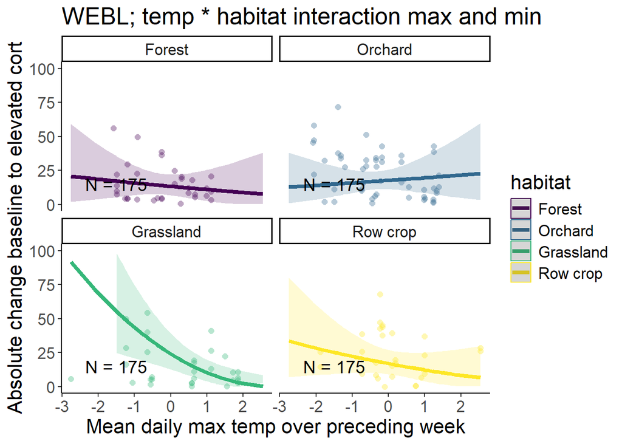

### TRES

#### cort_s1

| model | npar | AIC | BIC | logLik | deviance | Chisq | Df | Pr(>Chisq) |
| --- | --- | --- | --- | --- | --- | --- | --- | --- |
| no int | 11 | 195.7556 | 224.9492 | -86.87782 | 173.7556 | NA | NA | NA |
| int max | 14 | 201.4932 | 238.6487 | -86.74661 | 173.4932 | 0.2624275 | 3 | 0.966932688 |
| int max and min | 17 | 192.0219 | 237.1392 | -79.01093 | 158.0219 | 15.4713434 | 3 | 0.001455104 |

| model | npar | AIC | BIC | logLik | deviance | Chisq | Df | Pr(>Chisq) |
| --- | --- | --- | --- | --- | --- | --- | --- | --- |
| no int | 11 | 195.7556 | 224.9492 | -86.87782 | 173.7556 | NA | NA | NA |
| int min | 14 | 190.3212 | 227.4767 | -81.16062 | 162.3212 | 11.434397 | 3 | 0.009594552 |
| int max and min | 17 | 192.0219 | 237.1392 | -79.01093 | 158.0219 | 4.299374 | 3 | 0.230899054 |

For cort_s1 in TRES, there is an interaction with min but not with max.

```
## Linear mixed model fit by REML. t-tests use Satterthwaite's method [
## lmerModLmerTest]
## Formula: sqrt(cort_s1) ~ meanmaxtempI_scaled + meanmintempI_scaled * habitat +
##     age_scaled + juliandate_scaled + year_fct + (1 | attempt_id)
##    Data:
## dplyr::filter(g, Species == "TRES", !is.na(meanmaxtempI), !is.na(meanmintempI)) %>%
##     mutate(across(c(gweight, meanmaxtempI, meanmintempI, juliandate,
##         brood_size, age), ~scale(.x)[, 1], .names = "{.col}_scaled"),
##         meanmaxtempI_scaled_sq = meanmaxtempI_scaled * meanmaxtempI_scaled)
##
## REML criterion at convergence: 192.1
##
## Scaled residuals:
##      Min       1Q   Median       3Q      Max
## -1.87007 -0.67688 -0.02824  0.59405  2.22421
##
## Random effects:
##  Groups     Name        Variance Std.Dev.
##  attempt_id (Intercept) 0.02492  0.1579
##  Residual               0.29092  0.5394
## Number of obs: 105, groups:  attempt_id, 41
##
## Fixed effects:
##                                      Estimate Std. Error       df t value
## (Intercept)                           2.74758    0.24108 51.02272  11.397
## meanmaxtempI_scaled                   0.15515    0.11570 35.64893   1.341
## meanmintempI_scaled                  -0.49380    0.27000 44.33393  -1.829
## habitatOrchard                       -0.25367    0.26269 36.65652  -0.966
## habitatGrassland                     -0.47970    0.25425 44.92690  -1.887
## habitatRow crop                      -0.20862    0.25541 39.85628  -0.817
## age_scaled                            0.02249    0.07211 59.07912   0.312
## juliandate_scaled                     0.05098    0.07693 31.11036   0.663
## year_fct2023                          0.03615    0.16014 27.97725   0.226
## meanmintempI_scaled:habitatOrchard    1.04793    0.36273 37.36057   2.889
## meanmintempI_scaled:habitatGrassland  0.39479    0.27358 44.77152   1.443
## meanmintempI_scaled:habitatRow crop   0.33685    0.32020 40.55270   1.052
##                                      Pr(>|t|)
## (Intercept)                          1.23e-15 ***
## meanmaxtempI_scaled                    0.1884
## meanmintempI_scaled                    0.0741 .
```

[output cut: 22 more lines]

```
## mnmntmpI_:O  0.408  0.257 -0.792 -0.290 -0.383 -0.236  0.135  0.028 -0.231
## mnmntmpI_:G  0.330  0.048 -0.951 -0.241 -0.295 -0.241  0.052  0.047 -0.145
## mnmntmI_:Rc  0.128 -0.055 -0.787 -0.181 -0.159 -0.463  0.177  0.117  0.106
##             mnI_:O mnI_:G
## mnmxtmpI_sc
## mnmntmpI_sc
## habttOrchrd
## hbttGrsslnd
## habittRwcrp
## age_scaled
## julndt_scld
## yer_fct2023
## mnmntmpI_:O
## mnmntmpI_:G  0.750
## mnmntmI_:Rc  0.565  0.761
```

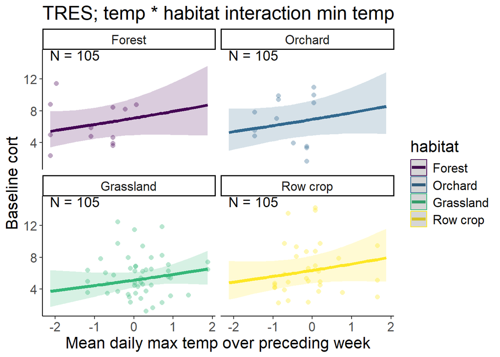

#### abs_change_cort

| model | npar | AIC | BIC | logLik | deviance | Chisq | Df | Pr(>Chisq) |
| --- | --- | --- | --- | --- | --- | --- | --- | --- |
| no int | 11 | 346.8029 | 373.0052 | -162.4014 | 324.8029 | NA | NA | NA |
| int max | 14 | 346.0301 | 379.3784 | -159.0150 | 318.0301 | 6.772826 | 3 | 0.07950210 |
| int max and min | 17 | 345.0014 | 385.4959 | -155.5007 | 311.0014 | 7.028653 | 3 | 0.07099008 |

| model | npar | AIC | BIC | logLik | deviance | Chisq | Df | Pr(>Chisq) |
| --- | --- | --- | --- | --- | --- | --- | --- | --- |
| no int | 11 | 346.8029 | 373.0052 | -162.4014 | 324.8029 | NA | NA | NA |
| int min | 14 | 350.9006 | 384.2489 | -161.4503 | 322.9006 | 1.902323 | 3 | 0.592925235 |
| int max and min | 17 | 345.0014 | 385.4959 | -155.5007 | 311.0014 | 11.899156 | 3 | 0.007736716 |

For abs_change in TRES, there is an interaction with max and marginally min.

```
## Linear mixed model fit by REML. t-tests use Satterthwaite's method [
## lmerModLmerTest]
## Formula:
## sqrt(abs_change_cort) ~ meanmaxtempI_scaled * habitat + meanmintempI_scaled *
##     habitat + age_scaled + juliandate_scaled + year_fct + (1 |      attempt_id)
##    Data:
## dplyr::filter(g, Species == "TRES", !is.na(meanmaxtempI), !is.na(meanmintempI)) %>%
##     mutate(across(c(gweight, meanmaxtempI, meanmintempI, juliandate,
##         brood_size, age), ~scale(.x)[, 1], .names = "{.col}_scaled"),
##         meanmaxtempI_scaled_sq = meanmaxtempI_scaled * meanmaxtempI_scaled)
##
## REML criterion at convergence: 301.3
##
## Scaled residuals:
##      Min       1Q   Median       3Q      Max
## -2.20483 -0.41441  0.06031  0.47900  2.21763
##
## Random effects:
##  Groups     Name        Variance Std.Dev.
##  attempt_id (Intercept) 0.8046   0.897
##  Residual               2.9455   1.716
## Number of obs: 80, groups:  attempt_id, 38
##
## Fixed effects:
##                                      Estimate Std. Error      df t value
## (Intercept)                            5.1321     1.8069 28.0454   2.840
## meanmaxtempI_scaled                    0.2308     1.1989 21.5362   0.193
## habitatOrchard                        -1.8556     2.0333 26.0190  -0.913
## habitatGrassland                      -0.3407     1.7525 28.8938  -0.194
## habitatRow crop                        0.1253     1.8575 29.4513   0.067
## meanmintempI_scaled                    0.8938     1.1541 28.6955   0.774
## age_scaled                             0.4067     0.3954 31.4840   1.029
## juliandate_scaled                     -0.1266     0.3374 19.3013  -0.375
## year_fct2023                           0.8582     0.6820 19.4918   1.258
## meanmaxtempI_scaled:habitatOrchard    -3.8641     2.0056 19.1004  -1.927
## meanmaxtempI_scaled:habitatGrassland   1.2144     1.3963 26.5332   0.870
## meanmaxtempI_scaled:habitatRow crop   -0.0609     1.3669 21.6848  -0.045
## habitatOrchard:meanmintempI_scaled    -3.3255     1.6400 25.4258  -2.028
## habitatGrassland:meanmintempI_scaled  -0.9344     1.2388 27.9084  -0.754
## habitatRow crop:meanmintempI_scaled   -0.7136     1.4893 25.9842  -0.479
##                                      Pr(>|t|)
## (Intercept)                            0.0083 **
## meanmaxtempI_scaled                    0.8491
## habitatOrchard                         0.3698
## habitatGrassland                       0.8472
## habitatRow crop                        0.9467
## meanmintempI_scaled                    0.4450
## age_scaled                             0.3115
## juliandate_scaled                      0.7115
## year_fct2023                           0.2231
## meanmaxtempI_scaled:habitatOrchard     0.0690 .
## meanmaxtempI_scaled:habitatGrassland   0.3922
## meanmaxtempI_scaled:habitatRow crop    0.9649
## habitatOrchard:meanmintempI_scaled     0.0532 .
## habitatGrassland:meanmintempI_scaled   0.4570
## habitatRow crop:meanmintempI_scaled    0.6358
## ---
## Signif. codes:  0 '***' 0.001 '**' 0.01 '*' 0.05 '.' 0.1 ' ' 1
```

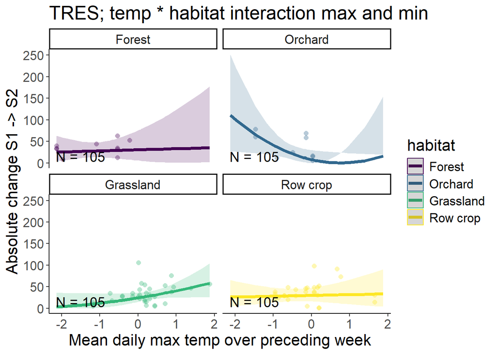

I think given this finding it might be helpful to subset the TRES data down to just grassland and row crop to compare them. Sample size for forest and orchard are so small.